# Example Report Template for a Data Analysis Project

Author

Rebecca Basta and Katherine Lorusso

This uses [HTML as output format](https://quarto.org/docs/output-formats/html-basics.html). See [the Quarto documentation](https://quarto.org/) for instructions on how to use other formats.

# 1 Methods

The dataset was loaded from the processed-data folder using the `here` package. Linear regression models were fit using the `lm()` function. The first one is a linear model with height as the outcome and weight as the predictor. The secone one is a multiple linear model with height as the outcome and weight and gender as predictors. The third one is a few linear models with height as the outcome and study time and exercise time as predictors. Model results were cleaned up using the `broom` package and saved as RDS files in the results/tables folder. Figures generated during analysis were saved to the results/figures folder.

# 2 Results

```r
library(here)

# Load saved tables
result1 <- readRDS(here("results", "tables", "resulttable1.rds"))
result2 <- readRDS(here("results", "tables", "resulttable2.rds"))
result3 <- readRDS(here("results", "tables", "resulttable3.rds"))

result1
```

```
         term    estimate  std.error statistic      p.value
1 (Intercept) 149.6997661 19.7518528 7.5790240 0.0001285084
2      Weight   0.2277371  0.2708841 0.8407177 0.4282859783
```

```r
result2
```

```
         term    estimate  std.error  statistic     p.value
1 (Intercept) 149.2726967 23.3823360  6.3839942 0.001396202
2      Weight   0.2623972  0.3512436  0.7470519 0.488651747
3     GenderM  -2.1244913 15.5488953 -0.1366329 0.896652025
4     GenderO  -4.7644739 19.0114155 -0.2506112 0.812087104
```

```r
result3
```

```
          term      estimate    std.error  statistic      p.value
1  (Intercept) 161.089286648 12.869001653 12.5176211 1.589696e-05
2 Exercisetime  -0.030542742  0.118496421 -0.2577524 8.052106e-01
3    Studytime   0.001656239  0.002921644  0.5668859 5.913515e-01
```

## 2.1 Exploratory/Descriptive analysis

| skim_type | skim_variable | n_missing | complete_rate | factor.ordered | factor.n_unique | factor.top_counts | numeric.mean | numeric.sd | numeric.p0 | numeric.p25 | numeric.p50 | numeric.p75 | numeric.p100 | numeric.hist |
| --- | --- | --- | --- | --- | --- | --- | --- | --- | --- | --- | --- | --- | --- | --- |
| factor | Gender | 0 | 1 | FALSE | 3 | M: 4, F: 3, O: 2 | NA | NA | NA | NA | NA | NA | NA | NA |
| numeric | Height | 0 | 1 | NA | NA | NA | 165.66667 | 15.97655 | 133 | 156 | 166 | 178 | 183 | ▂▁▃▃▇ |
| numeric | Weight | 0 | 1 | NA | NA | NA | 70.11111 | 21.24526 | 45 | 55 | 70 | 80 | 110 | ▇▂▃▂▂ |

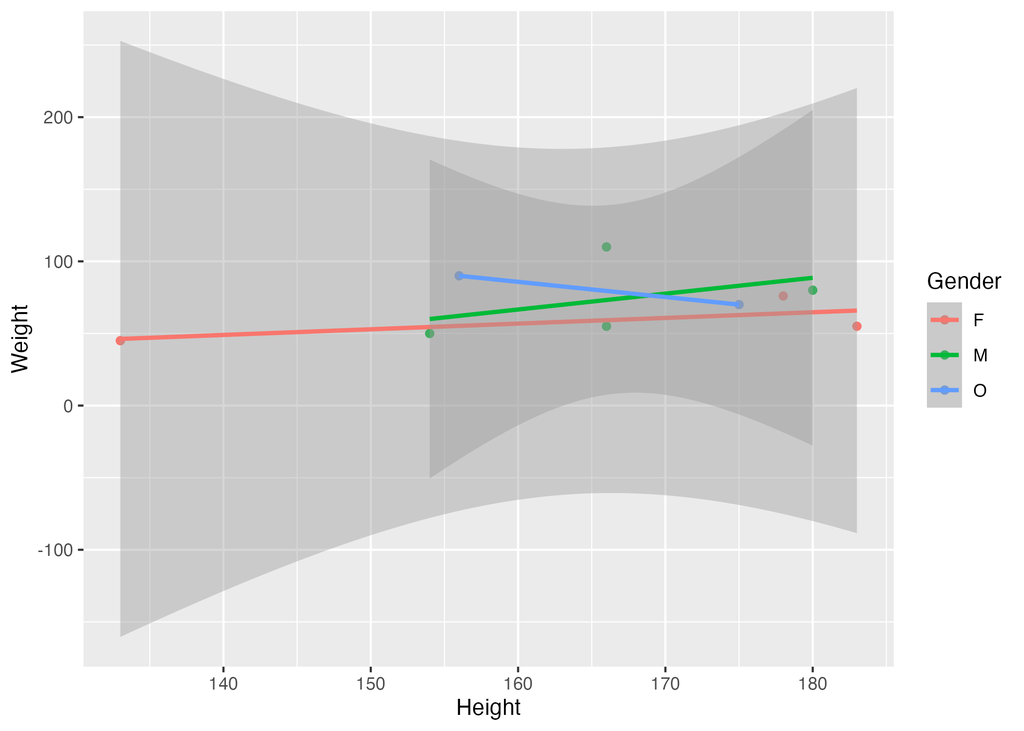

Figure 1: Height and weight stratified by gender.

## 2.2 Full analysis

Table 2: Linear model fit table.

| term | estimate | std.error | statistic | p.value |
| --- | --- | --- | --- | --- |
| (Intercept) | 149.2726967 | 23.3823360 | 6.3839942 | 0.0013962 |
| Weight | 0.2623972 | 0.3512436 | 0.7470519 | 0.4886517 |
| GenderM | -2.1244913 | 15.5488953 | -0.1366329 | 0.8966520 |
| GenderO | -4.7644739 | 19.0114155 | -0.2506112 | 0.8120871 |